# FIE4-2-IMTNS-2-Course-1

Adrien Wartelle

2026-01-06

## i (S1) - Page de garde

**E.C. Outils d’Analyse et de Modélisation des Flux en Santé**

**U.E. E4-2-IMTNS Ingénierie et Management de la Transformation Numérique en Santé**

2025-2026

Adrien Wartelle (adrien.wartelle@univ-jfc.fr)

## ii (S2) - Objectifs du module

- Pouvoir, savoir :
  - Analyser un **jeu de données** lié à un **processus** de flux en santé grâce aux fondements de la **science des données**
  - Mettre en place des **modèles de file d’attente** analytiques et de simulation
  - Entamer une **modélisation axée sur les données** grâce au Process Mining
  - Suivre une **démarche scientifique et critique** fondée sur une validation conceptuelle et numérique

## iii (S3-S7) - Références complémentaires

- Référence pour l’analyse :
  - Wickham, H., & Grolemund, G: R for data science (Vol. 2). Sebastopol : O’Reilly. (2017).

[figure not shown]

*R for Data Science*

- Référence pour la modélisation :
  - Shortle, J.F., Thompson, J.M., Gross, D., Harris, C.M.: Fundamentals of Queueing Theory: Fifth Edition. John Wiley & Sons, Inc. (2017).

[figure not shown]

*Fundamentals of Queueing Theory*

- Articles de référence (non exhaustifs) pour la modélisation du système de soins :
  - Badr, S., Nyce, A., Awan, T., Cortes, D., Mowdawalla, C., Rachoin, J.-S.: Measures of emergency department crowding, a systematic review. how to make sense of a long list. Open Access Emergency Medicine, 5–14 (2022)
  - Bhattacharjee P, Ray PK. Patient flow modelling and performance analysis of healthcare delivery processes in hospitals: A review and reflections. Computers & Industrial Engineering. 2014;78:299-312
- Internet
  - https://education.rstudio.com/learn/beginner/
  - https://anylogic.help/tutorials/index.html
  - https://demo.bpmn.io
  - Formation udemy : « The Practical BPMN 2.0 Master Class »

## iv (S8-S9) - Organisation

- Séances (hybrides)

  | Date | Modalité | Contenu | Evaluation |
  | --- | --- | --- | --- |
  | Ma13/01 | 2h CM + 2h TD/TP | Introduction au module et à l’analyse (EDA) | Début devoir 1 (pour le 25/01) |
  | L19/01 | 2h CM + 2h TD/TP | Introduction à la modélisation par file d’attente | Début devoir 2 (pour le 01/02) |
  | Ma27/01 | 2h CM + 2h TD/TP | Simulation 1 sous Anylogic | Début devoir 3 (pour le 08/02) |
  | Ma03/02 | 2h CM + 2h TD/TP | Process Mining et Simulation 2 sous Anylogic | Début devoir 4 (pour le 17/02) |
  | Ma10/02 | 4h TD/TP | Démarche de validation et correction | Correction devoir 1 à 3 |
  | Ma17/02 | Soutenances (2h) | Évaluation et correction | Examen (devoir 4 et +) |

- Modalité d’évaluation
  - Devoir 1 : Livrable **numérique, individuel** de coefficient **20%**
  - Devoir 2 : Livrable **manuscrit / numérique, individuel** de coefficient **20%**
  - Devoir 3 : Livrable **numérique**, en **groupe de 2** de coefficient **30%**
  - Devoir 4 : Livrables numérique / manuscrits / oraux, en **groupe de 2** de coefficient **30%**

## I (S10) - Les flux en santé

Dans l’abstrait et le concret

### I.1 (S11) - Définition du cours

- Un flux est une **quantité homogène, continue et/ou discrète**, qui se déplace au **cours du temps** dans un **espace d’état, continu et/ou discret**
- Les flux circulent au sein d’un **réseau d’interconnexion** connectant les **éléments d’un système** et sont nécessaires à son fonctionnement **fonctionnement**
- **Quelques caractéristiques intrinsèques :**

  | Etats continus | Etats discrets |
  | --- | --- |
  | Déplacement continue | Transition instantanée |
  | Vitesse | Taux de transition unitaire |
  | Débit | Taux de transition par groupe |
  | Densité | Stocks |

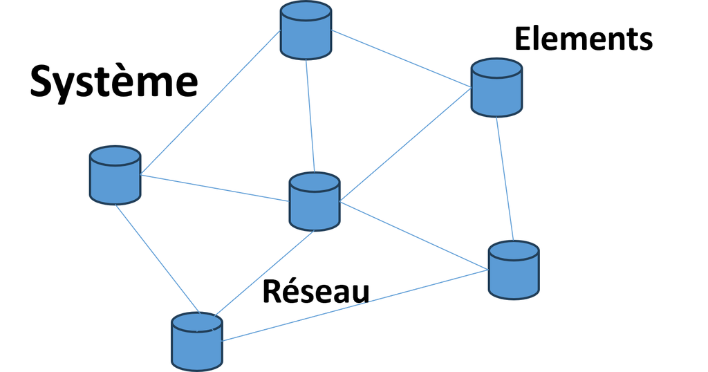

*Représentation d’un système*

### I.2 (S12) - Les différents types de flux en santé

Les flux en santé sont nombreux. Pour la plupart, ils sont à états discrets bien qu’à large échelle une approximation continue soit possible. On peut noter :

- Flux de patient
- Flux de personnel
- Flux de transport
- Flux de linge
- Flux de médicaments
- Flux d’argent
- Flux d’électricité, d’eau

Dans ce cours, on s’intéressera principalement aux **flux de patient** et secondairement aux **flux de personnel**.

### I.3 (S13) - Notion de parcours patient

Les flux de patient s’inscrivent dans le cadre d’un **parcours patient = trajectoire du patient = parcours thérapeutique du patient = parcours de soins**

Il traduit le cheminement du patient au travers des **activités de soins** qui lui ont été prescrites dans le cadre de sa prise en charge thérapeutique

[figure not shown]

*Schéma du parcours d’un parcours patient avec les différentes activités*

### I.4 (S14) - Typologie des parcours

- **Parcours de soins** : le juste enchainement, au bon moment des différences compétences professionnelles, liées directement ou indirectement aux soins: consultations, actes techniques ou biologiques, traitements médicamenteux et non médicamenteux, prise en charge des épisodes aigus
- **Parcours de santé** : parcours de soins articulé en amont avec la prévention primaire et sociale et en aval, avec l’accompagnement médico-social et social, le maintien et le retour à domicile ;
- **Parcours de vie** : est une réponse aux besoins de la personne dans son environnement, intégrant des interactions avec la sphère sociétale, notamment l’éducation et l’emploi. Par essence, chaque individu a un seul parcours de vie qui court de sa naissance à son décès.

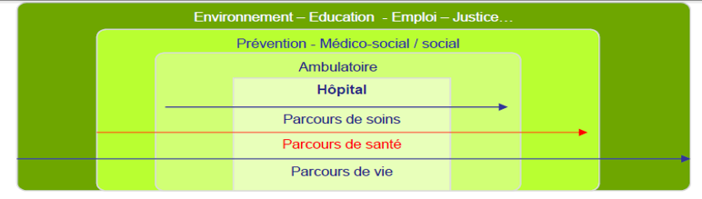

*Les typologies de parcours à différentes échelles*

### I.5 (S15) - Complexité des flux et des parcours patient

- Les flux et les parcours patient se complexifie avec le **périmètre d’étude**

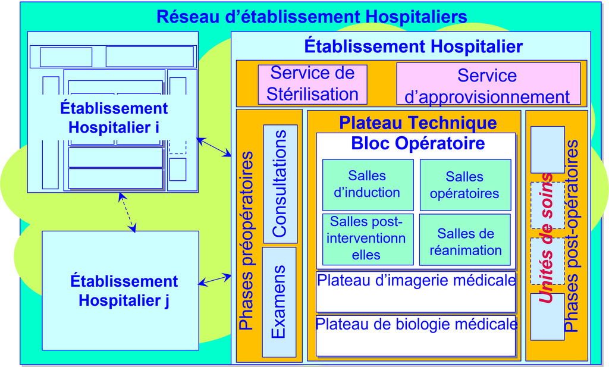

*Schéma d’un Réseau d’établissement Hospitaliers*

### I.6 (S16) - Comment les analyser / modéliser les flux patients

Comme toute **démarche scientifique**, l’analyse et la modélisation, en particulier des flux de patients, se fait à partir de plusieurs **sources d’informations** :

- **Humaines et conceptuelles**
  - les experts du système à travers des réunions, des interviews et des workshops
  - la litérature scientifique (articles, thèses, conférences)
- **Numériques et quantifiables**
  - les données collectées par des campagnes de mesures
  - les données collectées de manière systématique dans le SI
  - les données en *open data* (rares)

### I.7 (S17) - Les sources humaines

La science ne se construit pas dans un **“vide sociale”**. Cela exige un nombre important d’**interactions** d’idées, de compétences et de points de vue.

**Des discussions sont nécessaires** :

- **Avec les experts** pour comprendre et valider la structuration des systèmes, de ces flux et de ses données
- **Avec d’autres scientifiques** pour *challenger* et valider la démarche, c-à-d la méthode, les résultats les interpréatations et les contributions dans le cadre du corpus scientifique

### I.8 (S18) - Les sources numériques

Dans le cadre d’un système de soins avec un SI déjà établies, des données de santé administratives souvent dénommées *Eletronic Health Records* (EHRs) sons disponibles. Elles sont associées aux dossiers patient à plusieurs échelles et structures (en France) :

- Soins de **villes** (CCAM et SNIIRAM)
- Soins en **cliniques**, unités de soins, urgences (Logiciels spécialisés comme RESURGENCES)
- Soins d’**hôpitaux** (PMSI)

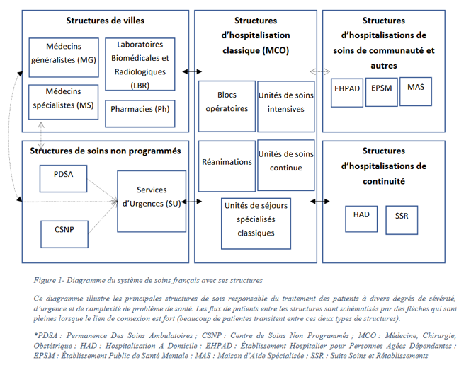

*Schéma des structures de soins en France*

### I.9 (S19) - Exploitation des sources numériques

L’exploitation des sources numériques se fait dans un cadre scientifique à travers la **science des statistiques** ou **science des données**. Celle à plusieurs visées qui se rapprochent progressivement des sciences d’**aide à la décision** (notamment la recherche opérationnelle) :

1. **Descriptive** : Comprendre les flux et le système sous-jacent - Comprendre la structure des données et métadonnées - Formuler des observations et des hypothèses - Synthétiser les données à travers du clustering d’individus ou de facteurs
2. **Prédictive** : Mettre en place des modèles qui **répliquent** des comportements de flux observés
3. **Prospective** : Mettre en place des modèles qui **extrapolent** ces comportements dans des situations non observés
4. **Prescriptive** : Mettre en place des modèles qui permette d’**agir**, de prendre des **décisions”** sur ces comportements

Aujourd’hui nous allons rester concentrer sur les statistiques **descriptives**

## II (S20) - *Statistics* 101

Une plongée synthétique sur les notions essentielles avec R.

### II.i (S21) - Histoire

L’éthymologie selon Wikipédia (janvier 2026) :

> “D’usage généralisé en français vers 1785, dérivé de l’italien statista (« homme d’État, statiste »), emprunté à l’allemand Statistik, forgé ou repris, vers 1749, par l’économiste Gottfried Achenwall : la statistique représentant pour lui l’ensemble des connaissances que doit posséder un homme d’État.”

Les statistiques sont utilisées initialement en économétrie comme outils de mesure et de contrôle des états sur leur territoires et leur économies.

De nos jours, notamment depuis depuis la numérisation du domaine à la fin du XXème et au début XXIème siècles, les statistiques sont regroupées au sein de la **science des données** (*data science*) avec les sciences de l’informatique et connaissance spécifiques aux domaine / problème / business étudiés.

Mais les statistiques sont le au fondement mathématique de la *data science*, du *Machine learning*, du *Deep Learning* et donc *LLM* avec un vocabulaire parfois différent mais les mêmes principes.

### II.ii (S22) - Utilité

A quoi servent les statistiques ?

**Extraire des informations et des connaissances synthétiques** à partir de données collectées sous la forme de description quantitative et qualitative, de modèles, de test d’hypothèses.

Comme on l’a vu en S19 avec les statistiques descriptives, prédictives, prospectives puis prescriptives, les statistiques cervent des objectifs de plus en plus complexes.

On s’en sert autant pour construire :

- **Connaissances scientifiques** réfutables par l’expérience (aka pas les maths).
  - Notion de statistiquement significatif et de p-value
- **Décisions** fondées sur des données (*data-driven*) ou par la science

### II.iii (S23) - De nos jours

Les statistiques se sont modernisées avec les systèmes d’informations et la numérisation des données. Il est toujours possible de les pratiquer avec des feuilles et un crayon (et une calculatrice) à des fins illustratives et pédagogiques. Cependant, des outils modernes très puissants existes, on distingue :

- Les logiciels spécialisés
  - Statistiques : SPSS, Stata, SPAD, SAS
  - Tableurs : Excel, LibreOffic calc
  - Logiciels scientifiques : Mathlab, Scilab, Octave
  - Logiciels de Process Mining : Celonis, Disco, EDS, Fujitsu, Minit, myInvenio, Perceptive, QPR, Risito, SNP, PPM
- Les langages de programmation
  - Compilé : C, C++, Java
  - Compilé juste à temps : julia
  - Scripts : R, Python

Dans ce cours, nous allons utilisé le langage de programmation R avec l’environnement de développement intégré (IDE) RStudio. Python est aussi une très bonne alternative avec différents *tradeoffs* car il est plus généraliste, mais donc aussi moins spécialisé.

### II.iv (S24) - R et RStudio

R est un langage de script spécialisé dans l’analyse statistique et la science des données. Sa communauté et son écosystème de libraries très riche avec tydiverse, data.table ou encore RShiny en font un choix idéal. L’utilisation intelligente du langage, de ses libraires et de son principal IDE en font une alternative plus pertinente que Python bien que moins populaire.

Installation : - [R] https://cran.r-project.org/bin/windows/base/ - [Rstudio] https://posit.co/download/rstudio-desktop/

### II.1 (S25) - Notions fondamentales

Une révision du vocabulaire et du contexte des statistiques

#### II.1.1 (S26) - Jeu de données exemple *mtcars*

Nous allons nous servir du jeu de données *mtcars* fournis dans la base du langage R pour illustrer les notions fondamentales des statistiques.

Il s’agit d’un petit jeu de données sur la caractérisation de voitures comme l’indique sa documentation : > “The data was extracted from the 1974 Motor Trend US magazine, and comprises fuel consumption and 10 aspects of automobile design and performance for 32 automobiles (1973–74 models).”

#### II.1.2 (S27) - La structure fondamentale : le tableau de données

En statistiques et en science des données, la structure fondamentales de travail est le tableau de données, ou *data frame*. qui contient un ensemble de lignes associés à des individus d’une population (ou unités d’analyse), et de colonnes associés à des variables.

```r
mtcars
```

```
##                      mpg cyl  disp  hp drat    wt  qsec vs am gear carb
## Mazda RX4           21.0   6 160.0 110 3.90 2.620 16.46  0  1    4    4
## Mazda RX4 Wag       21.0   6 160.0 110 3.90 2.875 17.02  0  1    4    4
## Datsun 710          22.8   4 108.0  93 3.85 2.320 18.61  1  1    4    1
## Hornet 4 Drive      21.4   6 258.0 110 3.08 3.215 19.44  1  0    3    1
## Hornet Sportabout   18.7   8 360.0 175 3.15 3.440 17.02  0  0    3    2
## Valiant             18.1   6 225.0 105 2.76 3.460 20.22  1  0    3    1
## Duster 360          14.3   8 360.0 245 3.21 3.570 15.84  0  0    3    4
## Merc 240D           24.4   4 146.7  62 3.69 3.190 20.00  1  0    4    2
## Merc 230            22.8   4 140.8  95 3.92 3.150 22.90  1  0    4    2
## Merc 280            19.2   6 167.6 123 3.92 3.440 18.30  1  0    4    4
## Merc 280C           17.8   6 167.6 123 3.92 3.440 18.90  1  0    4    4
## Merc 450SE          16.4   8 275.8 180 3.07 4.070 17.40  0  0    3    3
## Merc 450SL          17.3   8 275.8 180 3.07 3.730 17.60  0  0    3    3
## Merc 450SLC         15.2   8 275.8 180 3.07 3.780 18.00  0  0    3    3
## Cadillac Fleetwood  10.4   8 472.0 205 2.93 5.250 17.98  0  0    3    4
## Lincoln Continental 10.4   8 460.0 215 3.00 5.424 17.82  0  0    3    4
## Chrysler Imperial   14.7   8 440.0 230 3.23 5.345 17.42  0  0    3    4
## Fiat 128            32.4   4  78.7  66 4.08 2.200 19.47  1  1    4    1
## Honda Civic         30.4   4  75.7  52 4.93 1.615 18.52  1  1    4    2
## Toyota Corolla      33.9   4  71.1  65 4.22 1.835 19.90  1  1    4    1
## Toyota Corona       21.5   4 120.1  97 3.70 2.465 20.01  1  0    3    1
## Dodge Challenger    15.5   8 318.0 150 2.76 3.520 16.87  0  0    3    2
## AMC Javelin         15.2   8 304.0 150 3.15 3.435 17.30  0  0    3    2
## Camaro Z28          13.3   8 350.0 245 3.73 3.840 15.41  0  0    3    4
## Pontiac Firebird    19.2   8 400.0 175 3.08 3.845 17.05  0  0    3    2
## Fiat X1-9           27.3   4  79.0  66 4.08 1.935 18.90  1  1    4    1
## Porsche 914-2       26.0   4 120.3  91 4.43 2.140 16.70  0  1    5    2
## Lotus Europa        30.4   4  95.1 113 3.77 1.513 16.90  1  1    5    2
## Ford Pantera L      15.8   8 351.0 264 4.22 3.170 14.50  0  1    5    4
## Ferrari Dino        19.7   6 145.0 175 3.62 2.770 15.50  0  1    5    6
## Maserati Bora       15.0   8 301.0 335 3.54 3.570 14.60  0  1    5    8
## Volvo 142E          21.4   4 121.0 109 4.11 2.780 18.60  1  1    4    2
```

#### II.1.3 (S28) - Population, individus

```r
cat(paste(rownames(mtcars),collapse = "\n"))
```

```
## Mazda RX4
## Mazda RX4 Wag
## Datsun 710
## Hornet 4 Drive
## Hornet Sportabout
## Valiant
## Duster 360
## Merc 240D
## Merc 230
## Merc 280
## Merc 280C
## Merc 450SE
## Merc 450SL
## Merc 450SLC
## Cadillac Fleetwood
## Lincoln Continental
## Chrysler Imperial
## Fiat 128
## Honda Civic
## Toyota Corolla
## Toyota Corona
## Dodge Challenger
## AMC Javelin
## Camaro Z28
## Pontiac Firebird
## Fiat X1-9
## Porsche 914-2
## Lotus Europa
## Ford Pantera L
## Ferrari Dino
## Maserati Bora
## Volvo 142E
```

- **Population** : Échantillon de voitures des années 1973-1974
- **Individu / unité d’analyse** : une voiture
- Processus échantillonnage => **Biais de sélection**
  - Biais : Écart systématique d’un estimateur par rapport à la valeur estimée
  - Ici biais potentiel avec une limitation à 32 Voitures US populaires
- Individu dans le cadre de ce cours
  - un patient
  - un évènement de patient
  - un personnel médical
  - un médicaments
  - une salle

#### II.1.4 (S29-S30) - Variables et type de variables

```r
colnames(mtcars)
```

```
##  [1] "mpg"  "cyl"  "disp" "hp"   "drat" "wt"   "qsec" "vs"   "am"   "gear"
## [11] "carb"
```

*mtcars* contient 11(+1) variables décrites (documentation de R) comme ceci :

- mpg : Miles/(US) gallon
- cyl : Number of cylinders
- disp : Displacment (cu.in)
- hp : Gross horsepower
- drat : rear axle ratio
- wt : Weight (1000lbs)
- qsec : 1/4 mile time
- vs : Engine (0 = V-shaped, 1 = straight)
- am : Transmission (0 = automatic, 1 = manual)
- gear : Number of forward gears
- carb : Number of carburetors

On peut les classer selon deux modalités :

- Quantitative => nombre entiers, réels, vecteurs (…)
  - exemple ici : mpg, cyl, disp, hp, drat, wt, qsec, gear, carb
- Qualitative => texte non structurée, facteurs (…)
  - peut permettre de définir des groupes / sous population
  - exemple ici : rownames(mtcars), vs, am

```r
summary(as.factor(mtcars$am))
```

```
##  0  1
## 19 13
```

On peut classer les voitures en 2 groupes selon la variable *am* sur la transmission. On peut voir qu’il y a 19 voitures automatiques pour 13 manuelles, cohérent avec la préférence pour les voitures auto aux Etats-Unis

Processus de mesure des variables => **biais de mesures**, valeurs manquantes

- Biais de mesure probables (Risques) : mpg, wt, qsec
- Ici pas de valeur manquante NA

### II.2 (S31-S32) - Description des données et Indicateurs principaux

Avant de commencer, une petite vue globale sur le jeux de données *mtcars* :

```r
summary(mtcars[,1:4])
```

```
##       mpg             cyl             disp             hp
##  Min.   :10.40   Min.   :4.000   Min.   : 71.1   Min.   : 52.0
##  1st Qu.:15.43   1st Qu.:4.000   1st Qu.:120.8   1st Qu.: 96.5
##  Median :19.20   Median :6.000   Median :196.3   Median :123.0
##  Mean   :20.09   Mean   :6.188   Mean   :230.7   Mean   :146.7
##  3rd Qu.:22.80   3rd Qu.:8.000   3rd Qu.:326.0   3rd Qu.:180.0
##  Max.   :33.90   Max.   :8.000   Max.   :472.0   Max.   :335.0
```

```r
summary(mtcars[,5:8])
```

```
##       drat             wt             qsec             vs
##  Min.   :2.760   Min.   :1.513   Min.   :14.50   Min.   :0.0000
##  1st Qu.:3.080   1st Qu.:2.581   1st Qu.:16.89   1st Qu.:0.0000
##  Median :3.695   Median :3.325   Median :17.71   Median :0.0000
##  Mean   :3.597   Mean   :3.217   Mean   :17.85   Mean   :0.4375
##  3rd Qu.:3.920   3rd Qu.:3.610   3rd Qu.:18.90   3rd Qu.:1.0000
##  Max.   :4.930   Max.   :5.424   Max.   :22.90   Max.   :1.0000
```

```r
summary(mtcars[,9:11])
```

```
##        am              gear            carb
##  Min.   :0.0000   Min.   :3.000   Min.   :1.000
##  1st Qu.:0.0000   1st Qu.:3.000   1st Qu.:2.000
##  Median :0.0000   Median :4.000   Median :2.000
##  Mean   :0.4062   Mean   :3.688   Mean   :2.812
##  3rd Qu.:1.0000   3rd Qu.:4.000   3rd Qu.:4.000
##  Max.   :1.0000   Max.   :5.000   Max.   :8.000
```

On va se concentrer sur la variable *disp* sur le volume déplacé par les pistons du moteur et en cubic inch

```r
list(
  moyenne = mean(mtcars$disp),
  variabilite = var(mtcars$disp),
  ecart_type = sd(mtcars$disp),
  coefficient_de_variation = sd(mtcars$disp) / mean(mtcars$disp),
  median = median(mtcars$disp),
  difference_relative_median_moyenne = (mean(mtcars$disp) - median(mtcars$disp)) / median(mtcars$disp),
  quantiles = quantile(mtcars$disp))
```

```
## $moyenne
## [1] 230.7219
##
## $variabilite
## [1] 15360.8
##
## $ecart_type
## [1] 123.9387
##
## $coefficient_de_variation
## [1] 0.5371779
##
## $median
## [1] 196.3
##
## $difference_relative_median_moyenne
## [1] 0.1753534
##
## $quantiles
##      0%     25%     50%     75%    100%
##  71.100 120.825 196.300 326.000 472.000
```

Soit $X=(X_i)_{i \in \{1..n\}}$ des observations quantitatives avec $n \in \mathbb{N}$. On définit les indicateurs statistiques suivant :

- Moyenne : $m(X) = \frac{1}{n} \sum\_{i=1}\^n X_i$
- Variance (biaisé) : $V(X) = \frac{1}{n} \sum\_{i=1}\^n (m(X) - X_i)\^2 = m(X\^2) - m(X)\^2$
- Variance (non biaisé) : $V(X) = \frac{1}{n-1} \sum\_{i=1}\^n (m(X) - X_i)\^2 = m(X\^2) - m(X)\^2$
- Écart-type : $\sigma_X = \sqrt(V(X))$
- Coefficient de variation : $cv_X = \sigma_X / m(X)$
- Médiane et quantiles : $q_\alpha : \mathbb{P(X<\alpha) = q_\alpha}$

#### II.2.1 (S33) - Moyenne (statistique)

C’est la mesure par excellence pour synthétiser une variable quantitative. Il s’agit de la valeur que prendrait systématiquement une variable en cas d’absence de variabilité. L’absence de variabilité implique répartition avec équité parfaite des poids / ressources.

Il existe aussi d’autre type de moyennes comme la moyenne géométrique $G(a,b)=\sqrt(ab)$, ou harmonique $H=\frac{G^2}{A}$.

#### II.2.2 (S34) - Variance et Ecart type (statistiques)

Ils permettent de mesurer l’écart quadratique moyen à la moyenne. Cet mesure identifie plus facilement les forts écart que l’écart absolu moyen mais a une interprétation moins directe/ La Variance probabiliste présente des propriétés mathématiques et un plus intéressantes que l’écart absolue

#### II.2.3 (S35) - Médiane et quantiles

Ces mesures permettent d’obtenir des informations plus précises sur la distribution d’une variable. Les quantiles les plus fréquemment utilisés : 5%, 25%, 50% (Médiane), 75% et 95%

#### II.2.4 (S36) - Distribution et proportions

Dans le cas de variable non quantitatives $X_{quali}$ on mesure surtout des proportions $\mathbb{P}(X_{quali})$.

#### II.2.5 (S37) - Coefficient de variation

Pour juger du de la variabilité d’une variable, il est souvent intéressant de rapporter l’écart-type à la moyenne. C’est une mesure très importante en file d’attente comme nous le verrons dans le prochain cours.

Ici on constate un coefficient de variation raisonnable de 0.5.

#### II.2.6 (S38) - Moyenne vs médianne

La moyenne et la médiane peuvent diverger fortement avec de distributions très inégalitaires et asymétriques comme la distribution de salaires, de compétences, de temps d’attente dans un système à priorités.

La moyenne sera toujours une mesure synthétisant mieux une variable tandis que la médianne sera plus fidèle à la majorité des individus.

La moyenne est ici 17.5% supérieur à la médiane ici, indiquant une légère asymétrie avec une minorité de moteurs tirant la moyenne vers le haut comme semble le montre le quartiles / quantiles à 75%.

### II.3 (S39)- Les probabilités

Les probabilités et les statistiques sont complémentaires et distinguent principalement par la nature de leur approche.

Les probabilités partent de l’étude de **variable aléatoire** régie par des lois mathématiques de probabilité.

Les statistiques partent de l’étude de **variable statistique** observée sur des populations. Elles se servent de modèles, fondées notamment sur des lois de probabilités, pour expliquer ou extrapoler des observations / comportements.

#### II.3.1 (S40) - Cadre de définition d’une loi de probabilité

Une loi de probabilité est une mesure associé à un espace mesurable $(\Omega, \mathcal{A}, P)$ tel que $P: \mathcal{A} \to [0, 1]$ telle que $P(\Omega) = 1$ et que $P$ respecte l’additivité dénombrable (impliquant $P(AUB) = P(A) + P(B) + P(A et B)$).

Une **variable aléatoire** est une application qui associe des évènements d’un espace mesurable $(\Omega, \mathcal{A}, P)$ à des valeurs dans un espace mesurable réel de type $(\mathbb{R}^d, \mathcal{B}(\mathbb{R}^d), P)$ dans le cadre d’une variable aléatoire réelle. Une loi de probabilité $P$ peut se définir alors pour tous les ensembles $\omega$ dans la la tribu borélienne sur $\mathbb{R}^d$, c-à-d $\omega \in \mathcal{B}(\mathbb{R}^d)$ .

Sans rentrer dans les détails de la théorie de la mesure et des probabilités, on définit en général une loi de probabilité de deux manière différentes :

- Cas discret : en donnant directement les valeurs de probabilités $\mathbb(P)(X = x), \forall x \in X(\Omega)$
- Cas continu : à partir d’une densité de probabilité $f: x \to f(x)$ tel que $\mathbb(P)(X \in I(x,x+dx)) = f(x)dx$

#### II.3.2 (S41) - Loi Normale (ou Loi de Gauss)

La loi “reine” des statistiques, modélisant les phénomènes où de nombreux petits facteurs indépendants s’additionnent. La *loi des grands nombres* assurent la convergence de toutes additions de phénomènes aléatoires indépendants vers une loi normale.

- **Origine Historique :** Entre-aperçue par **Abraham de Moivre** en 1733 pour approximer la loi binomiale, elle est stabilisée par **Carl Friedrich Gauss** (1809) pour l’étude des erreurs de mesure en astronomie et par **Pierre-Simon de Laplace**.
- **Notation :** $X \sim \mathcal{N}(\mu, \sigma^2)$
- **Densité de probabilité :** $f(x) = \frac{1}{\sigma\sqrt{2\pi}} e^{-\frac{1}{2}\left(\frac{x-\mu}{\sigma}\right)^2}$
- **Espérance :** $E(X) = \mu$
- **Variance :** $V(X) = \sigma^2$

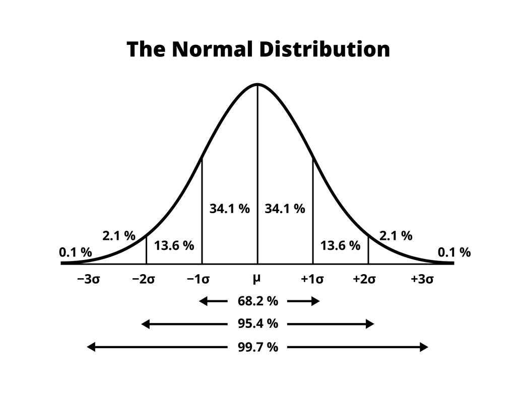

*Image of Normal distribution curve with standard deviations*

#### II.3.3 (S42) - Loi Binomiale et dérivée

Modélise le nombre de succès dans une répétition d’expériences de Bernoulli identiques et indépendantes.

- **Origine Historique :** Établie par **Jacob Bernoulli** dans son ouvrage *Ars Conjectandi* (publié à titre posthume en 1713). C’est la base de l’étude des tirages avec remise.
- **Notation :** $X \sim \mathcal{B}(n, p)$
- **Fonction de masse :** $P(X=k) = \binom{n}{k} p^k (1-p)^{n-k}$
- **Espérance :** $E(X) = np$
- **Variance :** $V(X) = np(1-p)$
- **Dérivée (Bernoulli) :** Si $n=1$, on obtient la loi de Bernoulli.

#### II.3.4 (S43) - Loi Exponentielle

Modélise le temps d’attente entre deux événements ou la durée de vie d’un système sans usure.

- **Origine Historique :** Liée aux travaux sur le calcul infinitésimal au XIXe siècle, elle devient centrale avec l’étude de la **désintégration radioactive** par **Ernest Rutherford** et la théorie de la fiabilité industrielle.
- **Notation :** $X \sim \mathcal{E}(\lambda)$
- **Densité de probabilité :** $f(x) = \lambda e^{-\lambda x}$ pour $x \ge 0$
- **Espérance :** $E(X) = \frac{1}{\lambda}$
- **Variance :** $V(X) = \frac{1}{\lambda^2}$

#### II.3.5 (S44) - Loi de Poisson

Dite “loi des événements rares”, elle décrit le nombre d’occurrences dans un intervalle fixe. Comme on le verra dans la théorie des files d’attentes, elle est directement reliée avec la loi exponenetielle qui est la loi que usit le temps entre 2 occurences.

- **Origine Historique :** Introduite par **Siméon Denis Poisson** en 1837 dans ses travaux sur la probabilité des jugements. Elle fut rendue célèbre par **Ladislaus Bortkiewicz** (1898) étudiant la fréquence des décès par coup de sabot dans l’armée prussienne.
- **Notation :** $X \sim \mathcal{P}(\lambda)$
- **Fonction de masse :** $P(X=k) = \frac{e^{-\lambda} \lambda^k}{k!}$
- **Espérance :** $E(X) = \lambda$
- **Variance :** $V(X) = \lambda$

#### II.3.6 (S45) - Loi Gamma

Généralisation de la loi exponentielle, elle modélise le temps d’attente pour obtenir $k$ événements.

- **Origine Historique :** Découle de la fonction Gamma introduite par **Leonhard Euler** (XVIIIe). Elle a été développée en statistique par **Karl Pearson** pour traiter les distributions asymétriques.
- **Notation :** $X \sim \Gamma(k, \theta)$
- **Densité de probabilité :** $f(x) = \frac{x^{k-1} e^{-\frac{x}{\theta}}}{\theta^k \Gamma(k)}$
- **Espérance :** $E(X) = k\theta$
- **Variance :** $V(X) = k\theta^2$

#### II.3.6 (S46) - Autres lois utiles

| Loi | Espérance | Contexte / Origine |
| --- | --- | --- |
| **Uniforme** $\mathcal{U}(a,b)$ | $\frac{a+b}{2}$ | Probabilité égale sur tout l’intervalle. |
| **Student** ($t$) | $0$ (si $n>1$) | **W. Gosset** (1908) pour Guinness (petits échantillons). |
| **Khi-deux** ($\chi^2$) | $k$ | **Karl Pearson** (1900) pour les tests d’ajustement. |
| **Pareto** | $\frac{\alpha x_m}{\alpha - 1}$ | **Vilfredo Pareto** (1896) sur les inégalités de revenus. |

### II.4. (S47) - Les bases de la modélisation : l’estimation

Estimateur : fonction des observables permettant d’estimer une caractéristique d’une loi de probabilité

Définition du biais

Définition d’Inférence, estimation, corrélation, regression linéaire (MC, MLE), classification et tests d’hypothèse

Estimation des moments d’une loi : on retrouve nos indicateurs statistiques principaux

#### II.4.1 (S48) - Estimation de la Moyenne (rappel)

- **Estimateur :** $\hat{\mu} = \bar{X} = \frac{1}{n} \sum X_i$
- **Propriété :** Sans biais si $E[\hat{\mu}] = \mu$.

#### II.4.2 (S49) - Estimation de la Variance (rappel)

- **Empirique :** $S^2 = \frac{1}{n} \sum (X_i - \bar{X})^2$
- **Corrigée :** $s^2 = \frac{1}{n-1} \sum (X_i - \bar{X})^2$

#### II.4.3 (S50) - Régression Linéaire (MCO)

On cherche à minimiser la somme des carrés des erreurs :
$$\min \sum (y_i - \hat{y}_i)^2$$
* **Pente :** $\hat{\beta}_1 = \frac{\sum(x_i-\bar{x})(y_i-\bar{y})}{\sum(x_i-\bar{x})^2}$ * **Intercepte :** $\hat{\beta}_0 = \bar{y} - \hat{\beta}_1\bar{x}$

#### II.4.4 (S51) - Maximum de Vraisemblance (MLE)

On cherche $\theta$ qui maximise :
$$\mathcal{L}(\theta) = \prod_{i=1}^n f(x_i |
\theta)$$
En pratique, on maximise la log-vraisemblance : $\ell(\theta) = \sum \ln f(x_i | \theta)$.

#### II.4.5 (S52) - Modèle Linéaire Généralisé (GLM)

Le GLM suppose que $E(Y) = \mu$ et $g(\mu) = X\beta$. * **Lien Logit (Logistique) :** $\ln(\frac{p}{1-p}) = X\beta$ * **Lien Log (Poisson) :** $\ln(\mu) = X\beta$

L’estimateur $\hat{\beta}$ est obtenu en résolvant les équations de score :
$$\frac{\partial \ell(\beta)}{\partial \beta} =
0$$

### II.4.6 (S53) - Régression Logistique (MLE)

Utilisée pour les variables binaires. La probabilité est définie par :
$$P(Y=1|X) = \sigma(X\beta) = \frac{1}{1 +
e^{-X\beta}}$$
L’estimation se fait par maximisation de la log-vraisemblance binomiale (Bernoulli) :
$$\ell(\beta) = \sum_{i=1}^n [y_i \ln(\hat{p}_i) +
(1-y_i) \ln(1-\hat{p}_i)]$$

## III (S54) Analyse Exploiratoire des Données

Première phase de travail avant toute modélisation, validation, ou décision.

### III.1 (S55) Définition

*Exploratory data Analysis*

Analyse non structurée visant à établir les caractéristiques un ensemble de données souvent structurée, à familiariser le ou les responsables d’analyse et à préparer le terrain pour une étude plus dirigée

Etape la plus longue (+ 50% du temps de travail, 90% du code) : le prétraitement des données

### III.2 (S56) - Objectifs dans le cas de données tabulaires

Données tabulaires : SQL, CSV, EXCEL, PARQUET … - Données se signaux : vidéos (RGBx3D), images (RGBx2D), son (1D) …

Objectifs : - Comprendre la structure des données et des métadonnées - Nombre, type et signification des variables (notamment codes et jargon) - Clés de la table (1 table, plusieurs tables ?)

- Transformer la structure des données
  - D’un format de colonnes à un autres
  - D’un format de fichier à un autre
- Faciliter l’exploitation en vue des objectifs d’analyse et de modélisation
- Nettoyer et filtrer les données de mauvaise qualité
- Quantifier l’exploitabilité des données

### III.2 (S57) - Utilisation de librairies

base R est rarement utilisé, peu optimisée et avec une mauvaise ergonomie Tidyverse est une librairie est beaucoup plus complet, ergonomique et performants. Lorsque les performances deviennent vraiment cruciale, il faut utiliser la libraire data.table (voir Rcpp ou C directement).

### III.9 (S58) - Mise en pratique

#### III.9.1 (S59) - Installer puis charger de la librairie

```r
# CTRL + ENTER to execute a command
# CTRL + MAJ + ENTER to execute a Rmd block
# install.packages("tidyverse") # to install tidyverse package
library(tidyverse)
# install.packages(data.table)
library(data.table)
```

#### III.9.2 (S60) - Créer un dataframe

Avec dplyr et tibble de tidyverse :

```r
dfA <- tibble(X1 = seq(1,10),
             X2 = seq(2,20,by=2),
             X3 = c(4,9,10,22,3,1,4,5,16,7),
             X4 = runif(10,0,10),
             X5 = rnorm(10,0,3),
             X6 = c("Hello","HELLO","HellO","Hi","BONJOUR",
                    "Bonjour","BonjourNo","Demo","DEMO","Text"),
             X7 = factor(X6))
dfA
```

```
## # A tibble: 10 × 7
##       X1    X2    X3    X4     X5 X6        X7
##    <int> <dbl> <dbl> <dbl>  <dbl> <chr>     <fct>
##  1     1     2     4 4.03   0.326 Hello     Hello
##  2     2     4     9 4.24   6.18  HELLO     HELLO
##  3     3     6    10 2.37   1.40  HellO     HellO
##  4     4     8    22 5.21   2.41  Hi        Hi
##  5     5    10     3 3.70   1.82  BONJOUR   BONJOUR
##  6     6    12     1 3.68   1.80  Bonjour   Bonjour
##  7     7    14     4 4.95  -2.93  BonjourNo BonjourNo
##  8     8    16     5 2.10  -1.75  Demo      Demo
##  9     9    18    16 4.59   6.32  DEMO      DEMO
## 10    10    20     7 0.815 -0.575 Text      Text
```

Avec data.table :

```r
dfB <-  data.table(X1 = seq(1,10),
                   X2 = seq(2,20,by=2),
                   X3 = c(4,9,10,22,3,1,4,5,16,7),
                   X4 = runif(10,0,10),
                   X5 = rnorm(10,0,3),
                   X6 = c("Hello","HELLO","HellO","Hi","BONJOUR",
                          "Bonjour","BonjourNo","Demo","DEMO","Text"))
dfB[, X7 := factor(X6)]
dfB
```

```
##     X1 X2 X3        X4         X5        X6        X7
##  1:  1  2  4 3.4816525  4.0082518     Hello     Hello
##  2:  2  4  9 5.1337368 -0.7733585     HELLO     HELLO
##  3:  3  6 10 2.4625932  0.6355403     HellO     HellO
##  4:  4  8 22 4.2125773 -3.6087912        Hi        Hi
##  5:  5 10  3 0.5518649  0.7538601   BONJOUR   BONJOUR
##  6:  6 12  1 6.5434800 -0.1340021   Bonjour   Bonjour
##  7:  7 14  4 5.8923547 -1.2130901 BonjourNo BonjourNo
##  8:  8 16  5 5.2860478 -0.3330943      Demo      Demo
##  9:  9 18 16 4.8937522 -3.3947682      DEMO      DEMO
## 10: 10 20  7 8.8861346  0.6745917      Text      Text
```

```r
dfB0 = copy(dfB) # for restoration purposes
```

#### III.9.3 (S61) - Ajouter des colonnes / variables

Avec tidyverse :

```r
dfA %>%
  mutate(Y1 = X1 / 2.,
         Y2 = X3 - 4)
```

```
## # A tibble: 10 × 9
##       X1    X2    X3    X4     X5 X6        X7           Y1    Y2
##    <int> <dbl> <dbl> <dbl>  <dbl> <chr>     <fct>     <dbl> <dbl>
##  1     1     2     4 4.03   0.326 Hello     Hello       0.5     0
##  2     2     4     9 4.24   6.18  HELLO     HELLO       1       5
##  3     3     6    10 2.37   1.40  HellO     HellO       1.5     6
##  4     4     8    22 5.21   2.41  Hi        Hi          2      18
##  5     5    10     3 3.70   1.82  BONJOUR   BONJOUR     2.5    -1
##  6     6    12     1 3.68   1.80  Bonjour   Bonjour     3      -3
##  7     7    14     4 4.95  -2.93  BonjourNo BonjourNo   3.5     0
##  8     8    16     5 2.10  -1.75  Demo      Demo        4       1
##  9     9    18    16 4.59   6.32  DEMO      DEMO        4.5    12
## 10    10    20     7 0.815 -0.575 Text      Text        5       3
```

```r
# equivalent to mutate(df, Y1 = X1 / 2., Y2 = X3 - 4)
```

Avec data.table :

```r
dfB[,Y1 := X1 / 2.][
  ,Y2 := X3 - 4] # or [, `:=`(Y1 = X1 / 2., Y2 = X3 - 4)]
dfB # what will be print
```

```
##     X1 X2 X3        X4         X5        X6        X7  Y1 Y2
##  1:  1  2  4 3.4816525  4.0082518     Hello     Hello 0.5  0
##  2:  2  4  9 5.1337368 -0.7733585     HELLO     HELLO 1.0  5
##  3:  3  6 10 2.4625932  0.6355403     HellO     HellO 1.5  6
##  4:  4  8 22 4.2125773 -3.6087912        Hi        Hi 2.0 18
##  5:  5 10  3 0.5518649  0.7538601   BONJOUR   BONJOUR 2.5 -1
##  6:  6 12  1 6.5434800 -0.1340021   Bonjour   Bonjour 3.0 -3
##  7:  7 14  4 5.8923547 -1.2130901 BonjourNo BonjourNo 3.5  0
##  8:  8 16  5 5.2860478 -0.3330943      Demo      Demo 4.0  1
##  9:  9 18 16 4.8937522 -3.3947682      DEMO      DEMO 4.5 12
## 10: 10 20  7 8.8861346  0.6745917      Text      Text 5.0  3
```

```r
# It has permanent effects so we remove it after
dfB = copy(dfB0)
```

#### III.9.4 (S62) - Trier selon une variable

Avec tidyverse :

```r
dfA %>%
  arrange(X3)
```

```
## # A tibble: 10 × 7
##       X1    X2    X3    X4     X5 X6        X7
##    <int> <dbl> <dbl> <dbl>  <dbl> <chr>     <fct>
##  1     6    12     1 3.68   1.80  Bonjour   Bonjour
##  2     5    10     3 3.70   1.82  BONJOUR   BONJOUR
##  3     1     2     4 4.03   0.326 Hello     Hello
##  4     7    14     4 4.95  -2.93  BonjourNo BonjourNo
##  5     8    16     5 2.10  -1.75  Demo      Demo
##  6    10    20     7 0.815 -0.575 Text      Text
##  7     2     4     9 4.24   6.18  HELLO     HELLO
##  8     3     6    10 2.37   1.40  HellO     HellO
##  9     9    18    16 4.59   6.32  DEMO      DEMO
## 10     4     8    22 5.21   2.41  Hi        Hi
```

```r
# equivalent to arrange(df, X3)

dfA %>%
  arrange(desc(X3))
```

```
## # A tibble: 10 × 7
##       X1    X2    X3    X4     X5 X6        X7
##    <int> <dbl> <dbl> <dbl>  <dbl> <chr>     <fct>
##  1     4     8    22 5.21   2.41  Hi        Hi
##  2     9    18    16 4.59   6.32  DEMO      DEMO
##  3     3     6    10 2.37   1.40  HellO     HellO
##  4     2     4     9 4.24   6.18  HELLO     HELLO
##  5    10    20     7 0.815 -0.575 Text      Text
##  6     8    16     5 2.10  -1.75  Demo      Demo
##  7     1     2     4 4.03   0.326 Hello     Hello
##  8     7    14     4 4.95  -2.93  BonjourNo BonjourNo
##  9     5    10     3 3.70   1.82  BONJOUR   BONJOUR
## 10     6    12     1 3.68   1.80  Bonjour   Bonjour
```

```r
# equivalent to arrange(df, -X3) (car X3 est une valeur numérique)
```

Avec data.table :

```r
setorder(dfB, X3)
dfB
```

```
##     X1 X2 X3        X4         X5        X6        X7
##  1:  6 12  1 6.5434800 -0.1340021   Bonjour   Bonjour
##  2:  5 10  3 0.5518649  0.7538601   BONJOUR   BONJOUR
##  3:  1  2  4 3.4816525  4.0082518     Hello     Hello
##  4:  7 14  4 5.8923547 -1.2130901 BonjourNo BonjourNo
##  5:  8 16  5 5.2860478 -0.3330943      Demo      Demo
##  6: 10 20  7 8.8861346  0.6745917      Text      Text
##  7:  2  4  9 5.1337368 -0.7733585     HELLO     HELLO
##  8:  3  6 10 2.4625932  0.6355403     HellO     HellO
##  9:  9 18 16 4.8937522 -3.3947682      DEMO      DEMO
## 10:  4  8 22 4.2125773 -3.6087912        Hi        Hi
```

```r
setorder(dfB, -X3)
dfB
```

```
##     X1 X2 X3        X4         X5        X6        X7
##  1:  4  8 22 4.2125773 -3.6087912        Hi        Hi
##  2:  9 18 16 4.8937522 -3.3947682      DEMO      DEMO
##  3:  3  6 10 2.4625932  0.6355403     HellO     HellO
##  4:  2  4  9 5.1337368 -0.7733585     HELLO     HELLO
##  5: 10 20  7 8.8861346  0.6745917      Text      Text
##  6:  8 16  5 5.2860478 -0.3330943      Demo      Demo
##  7:  1  2  4 3.4816525  4.0082518     Hello     Hello
##  8:  7 14  4 5.8923547 -1.2130901 BonjourNo BonjourNo
##  9:  5 10  3 0.5518649  0.7538601   BONJOUR   BONJOUR
## 10:  6 12  1 6.5434800 -0.1340021   Bonjour   Bonjour
```

```r
dfB = copy(dfB0)
```

#### III.9.5 (S63) - Enchaîner des opérations

Avec tidyverse :

```r
dfA %>%
  mutate(Y1 = X1 / 2.,
         Y2 = X3 - 4) %>%
  arrange(X3)
```

```
## # A tibble: 10 × 9
##       X1    X2    X3    X4     X5 X6        X7           Y1    Y2
##    <int> <dbl> <dbl> <dbl>  <dbl> <chr>     <fct>     <dbl> <dbl>
##  1     6    12     1 3.68   1.80  Bonjour   Bonjour     3      -3
##  2     5    10     3 3.70   1.82  BONJOUR   BONJOUR     2.5    -1
##  3     1     2     4 4.03   0.326 Hello     Hello       0.5     0
##  4     7    14     4 4.95  -2.93  BonjourNo BonjourNo   3.5     0
##  5     8    16     5 2.10  -1.75  Demo      Demo        4       1
##  6    10    20     7 0.815 -0.575 Text      Text        5       3
##  7     2     4     9 4.24   6.18  HELLO     HELLO       1       5
##  8     3     6    10 2.37   1.40  HellO     HellO       1.5     6
##  9     9    18    16 4.59   6.32  DEMO      DEMO        4.5    12
## 10     4     8    22 5.21   2.41  Hi        Hi          2      18
```

```r
# equivalent to arrange(mutate(df, Y1 = X1 / 2., Y2 = X3 - 4), X3)
```

Avec data.table : dfB[][][]… à préférer en général mais ici on ne peut pas

```r
dfB[,Y1 := X1 / 2.][
  ,Y2 := X3 - 4] # avoid using %>% here, it malfunctions
setorder(dfB,X3)
dfB
```

```
##     X1 X2 X3        X4         X5        X6        X7  Y1 Y2
##  1:  6 12  1 6.5434800 -0.1340021   Bonjour   Bonjour 3.0 -3
##  2:  5 10  3 0.5518649  0.7538601   BONJOUR   BONJOUR 2.5 -1
##  3:  1  2  4 3.4816525  4.0082518     Hello     Hello 0.5  0
##  4:  7 14  4 5.8923547 -1.2130901 BonjourNo BonjourNo 3.5  0
##  5:  8 16  5 5.2860478 -0.3330943      Demo      Demo 4.0  1
##  6: 10 20  7 8.8861346  0.6745917      Text      Text 5.0  3
##  7:  2  4  9 5.1337368 -0.7733585     HELLO     HELLO 1.0  5
##  8:  3  6 10 2.4625932  0.6355403     HellO     HellO 1.5  6
##  9:  9 18 16 4.8937522 -3.3947682      DEMO      DEMO 4.5 12
## 10:  4  8 22 4.2125773 -3.6087912        Hi        Hi 2.0 18
```

```r
dfB = copy(dfB0)
```

#### III.9.6 (S64) - Manipuler des catégories et des chaînes de caractères

Avec tidyverse :

```r
dfA2 <- dfA %>%
  mutate(X6 = tolower(X6),
         X6 = ifelse(str_detect(X6,"bonjour"),"bonjour",X6),
         X6 = ifelse(str_detect(X6,"hello"),"hello",X6),
         X6 = ifelse(!X6 %in% c("bonjour","hello"),
                     "others",X6),
         X7 = factor(X6),
         X7b = as.integer(X7))
dfA2
```

```
## # A tibble: 10 × 8
##       X1    X2    X3    X4     X5 X6      X7        X7b
##    <int> <dbl> <dbl> <dbl>  <dbl> <chr>   <fct>   <int>
##  1     1     2     4 4.03   0.326 hello   hello       2
##  2     2     4     9 4.24   6.18  hello   hello       2
##  3     3     6    10 2.37   1.40  hello   hello       2
##  4     4     8    22 5.21   2.41  others  others      3
##  5     5    10     3 3.70   1.82  bonjour bonjour     1
##  6     6    12     1 3.68   1.80  bonjour bonjour     1
##  7     7    14     4 4.95  -2.93  bonjour bonjour     1
##  8     8    16     5 2.10  -1.75  others  others      3
##  9     9    18    16 4.59   6.32  others  others      3
## 10    10    20     7 0.815 -0.575 others  others      3
```

Avec data.table :

```r
dfB[,X6 := tolower(X6)
    ][,X6 := ifelse(str_detect(X6,"bonjour"),"bonjour",X6)
    ][,X6 := ifelse(str_detect(X6,"hello"),"hello",X6)
    ][,X6 := ifelse(!X6 %in% c("bonjour","hello"),"others",X6)
    ][,X7 := factor(X6)
    ][,X7b := as.integer(X7)
]

dfB2 = copy(dfB)
dfB1 = copy(dfB) #for restoring
dfB = copy(dfB0)

dfB2
```

```
##     X1 X2 X3        X4         X5      X6      X7 X7b
##  1:  1  2  4 3.4816525  4.0082518   hello   hello   2
##  2:  2  4  9 5.1337368 -0.7733585   hello   hello   2
##  3:  3  6 10 2.4625932  0.6355403   hello   hello   2
##  4:  4  8 22 4.2125773 -3.6087912  others  others   3
##  5:  5 10  3 0.5518649  0.7538601 bonjour bonjour   1
##  6:  6 12  1 6.5434800 -0.1340021 bonjour bonjour   1
##  7:  7 14  4 5.8923547 -1.2130901 bonjour bonjour   1
##  8:  8 16  5 5.2860478 -0.3330943  others  others   3
##  9:  9 18 16 4.8937522 -3.3947682  others  others   3
## 10: 10 20  7 8.8861346  0.6745917  others  others   3
```

#### III.9.7 (S65) - Grouper des lignes (individus)

Avec tidyverse :

```r
dfA2 %>%
  group_by(X6)
```

```
## # A tibble: 10 × 8
## # Groups:   X6 [3]
##       X1    X2    X3    X4     X5 X6      X7        X7b
##    <int> <dbl> <dbl> <dbl>  <dbl> <chr>   <fct>   <int>
##  1     1     2     4 4.03   0.326 hello   hello       2
##  2     2     4     9 4.24   6.18  hello   hello       2
##  3     3     6    10 2.37   1.40  hello   hello       2
##  4     4     8    22 5.21   2.41  others  others      3
##  5     5    10     3 3.70   1.82  bonjour bonjour     1
##  6     6    12     1 3.68   1.80  bonjour bonjour     1
##  7     7    14     4 4.95  -2.93  bonjour bonjour     1
##  8     8    16     5 2.10  -1.75  others  others      3
##  9     9    18    16 4.59   6.32  others  others      3
## 10    10    20     7 0.815 -0.575 others  others      3
```

Avec data.table : dfB2[,…,by = .(X6)], groups are not conserved beyond an operation

#### III.9.8 (S66) - Appliquer un effet de groupement

Avec tidyverse :

```r
dfA2 %>%
  mutate(min_before = min(X2)) %>%
  group_by(X6) %>%
  mutate(min_after = min(X2))
```

```
## # A tibble: 10 × 10
## # Groups:   X6 [3]
##       X1    X2    X3    X4     X5 X6      X7        X7b min_before min_after
##    <int> <dbl> <dbl> <dbl>  <dbl> <chr>   <fct>   <int>      <dbl>     <dbl>
##  1     1     2     4 4.03   0.326 hello   hello       2          2         2
##  2     2     4     9 4.24   6.18  hello   hello       2          2         2
##  3     3     6    10 2.37   1.40  hello   hello       2          2         2
##  4     4     8    22 5.21   2.41  others  others      3          2         8
##  5     5    10     3 3.70   1.82  bonjour bonjour     1          2        10
##  6     6    12     1 3.68   1.80  bonjour bonjour     1          2        10
##  7     7    14     4 4.95  -2.93  bonjour bonjour     1          2        10
##  8     8    16     5 2.10  -1.75  others  others      3          2         8
##  9     9    18    16 4.59   6.32  others  others      3          2         8
## 10    10    20     7 0.815 -0.575 others  others      3          2         8
```

Avec data.table :

```r
dfB2[,min_before := min(X2)
     ][,min_after := min(X2), by = X6]
dfB2
```

```
##     X1 X2 X3        X4         X5      X6      X7 X7b min_before min_after
##  1:  1  2  4 3.4816525  4.0082518   hello   hello   2          2         2
##  2:  2  4  9 5.1337368 -0.7733585   hello   hello   2          2         2
##  3:  3  6 10 2.4625932  0.6355403   hello   hello   2          2         2
##  4:  4  8 22 4.2125773 -3.6087912  others  others   3          2         8
##  5:  5 10  3 0.5518649  0.7538601 bonjour bonjour   1          2        10
##  6:  6 12  1 6.5434800 -0.1340021 bonjour bonjour   1          2        10
##  7:  7 14  4 5.8923547 -1.2130901 bonjour bonjour   1          2        10
##  8:  8 16  5 5.2860478 -0.3330943  others  others   3          2         8
##  9:  9 18 16 4.8937522 -3.3947682  others  others   3          2         8
## 10: 10 20  7 8.8861346  0.6745917  others  others   3          2         8
```

```r
dfB2 = copy(dfB1)
```

#### III.9.9 (S67) - Combiner des lignes

Avec tidyverse :

```r
dfA2 %>%
  group_by(X6) %>%
  summarize(min_after = min(X2), .groups = 'drop') # dropping groups (same as ungroup())
```

```
## # A tibble: 3 × 2
##   X6      min_after
##   <chr>       <dbl>
## 1 bonjour        10
## 2 hello           2
## 3 others          8
```

Avec data.table :

```r
dfB2[, .(min_after = min(X2)), by = .(X6)]
```

```
##         X6 min_after
## 1:   hello         2
## 2:  others         8
## 3: bonjour        10
```

```r
dfB2 # not permanent effect when not using := or set
```

```
##     X1 X2 X3        X4         X5      X6      X7 X7b
##  1:  1  2  4 3.4816525  4.0082518   hello   hello   2
##  2:  2  4  9 5.1337368 -0.7733585   hello   hello   2
##  3:  3  6 10 2.4625932  0.6355403   hello   hello   2
##  4:  4  8 22 4.2125773 -3.6087912  others  others   3
##  5:  5 10  3 0.5518649  0.7538601 bonjour bonjour   1
##  6:  6 12  1 6.5434800 -0.1340021 bonjour bonjour   1
##  7:  7 14  4 5.8923547 -1.2130901 bonjour bonjour   1
##  8:  8 16  5 5.2860478 -0.3330943  others  others   3
##  9:  9 18 16 4.8937522 -3.3947682  others  others   3
## 10: 10 20  7 8.8861346  0.6745917  others  others   3
```

```r
dfB2 = copy(dfB1)
```

#### III.9.10 (S68) - Filtrer des lignes

Avec tidyverse :

```r
dfA2 %>%
  filter(X6 %in% c("bonjour","hello"))
```

```
## # A tibble: 6 × 8
##      X1    X2    X3    X4     X5 X6      X7        X7b
##   <int> <dbl> <dbl> <dbl>  <dbl> <chr>   <fct>   <int>
## 1     1     2     4  4.03  0.326 hello   hello       2
## 2     2     4     9  4.24  6.18  hello   hello       2
## 3     3     6    10  2.37  1.40  hello   hello       2
## 4     5    10     3  3.70  1.82  bonjour bonjour     1
## 5     6    12     1  3.68  1.80  bonjour bonjour     1
## 6     7    14     4  4.95 -2.93  bonjour bonjour     1
```

Avec data.table :

```r
dfB2[X6 %in% c("bonjour","hello")]
```

```
##    X1 X2 X3        X4         X5      X6      X7 X7b
## 1:  1  2  4 3.4816525  4.0082518   hello   hello   2
## 2:  2  4  9 5.1337368 -0.7733585   hello   hello   2
## 3:  3  6 10 2.4625932  0.6355403   hello   hello   2
## 4:  5 10  3 0.5518649  0.7538601 bonjour bonjour   1
## 5:  6 12  1 6.5434800 -0.1340021 bonjour bonjour   1
## 6:  7 14  4 5.8923547 -1.2130901 bonjour bonjour   1
```

```r
# not permanent effect
```

#### III.9.11 (S69) - Sélectionner des colonnes / variables

Avec tidyverse :

```r
dfA2 %>%
  filter(X6 %in% c("bonjour","hello")) %>%
  select(X6,X2)
```

```
## # A tibble: 6 × 2
##   X6         X2
##   <chr>   <dbl>
## 1 hello       2
## 2 hello       4
## 3 hello       6
## 4 bonjour    10
## 5 bonjour    12
## 6 bonjour    14
```

Avec data.table :

```r
dfB2[X6 %in% c("bonjour","hello"),.(X6,X2)]
```

```
##         X6 X2
## 1:   hello  2
## 2:   hello  4
## 3:   hello  6
## 4: bonjour 10
## 5: bonjour 12
## 6: bonjour 14
```

```r
# not permanent effect
```

#### III.9.12 (S70) - Reformater une colonne en plusieurs colonnes

Avec tidyverse :

```r
dfA2 %>%
  filter(X6 %in% c("bonjour","hello")) %>%
  select(X6,X2) %>%
  mutate(row = c(1,2,3,1,2,3)) %>%
  spread(X6,X2)
```

```
## # A tibble: 3 × 3
##     row bonjour hello
##   <dbl>   <dbl> <dbl>
## 1     1      10     2
## 2     2      12     4
## 3     3      14     6
```

Avec data.table :

```r
dfB2 <- dfB2[X6 %in% c("bonjour","hello"),.(X6,X2)]
dfB2[,row := c(1,2,3,1,2,3)]
dfB2
```

```
##         X6 X2 row
## 1:   hello  2   1
## 2:   hello  4   2
## 3:   hello  6   3
## 4: bonjour 10   1
## 5: bonjour 12   2
## 6: bonjour 14   3
```

```r
dcast(dfB2, row ~ X6, value.var = c("X2"))
```

```
##    row bonjour hello
## 1:   1      10     2
## 2:   2      12     4
## 3:   3      14     6
```

```r
dfB2 = copy(dfB1)
```

#### III.9.13 (S71) - Reformater plusieurs colonnes en une colonne

Avec tidyverse :

```r
dfA2 %>%
  filter(X6 %in% c("bonjour","hello")) %>%
  select(X6,X2) %>%
  mutate(row = c(1,2,3,1,2,3)) %>%
  spread(X6,X2) %>%
  gather(key = "X6",value = "X2",bonjour,hello)
```

```
## # A tibble: 6 × 3
##     row X6         X2
##   <dbl> <chr>   <dbl>
## 1     1 bonjour    10
## 2     2 bonjour    12
## 3     3 bonjour    14
## 4     1 hello       2
## 5     2 hello       4
## 6     3 hello       6
```

Avec data.table : ne marche pas sur la version actuelle

```r
# dfB2 <- dfB2[X6 %in% c("bonjour","hello"),.(X6,X2)]
# dfB2[,row := c(1,2,3,1,2,3)]
# dfB2
# dfB2 = dcast(dfB2, row ~ X6, value.var = c("X2"))
# melt(dfB2, measure.vars = data.table::measure(value.name, y, sep=""))
# dfB2 = copy(dfB1)
```

#### III.9.14 (S72) - Compacter des les données

Avec tidyverse :

```r
dfA2 %>%
  group_by(X6) %>%
  nest()
```

```
## # A tibble: 3 × 2
## # Groups:   X6 [3]
##   X6      data
##   <chr>   <list>
## 1 hello   <tibble [3 × 7]>
## 2 others  <tibble [4 × 7]>
## 3 bonjour <tibble [3 × 7]>
```

Avec data.table : pas disponible mais on peut faire ça par exemple :

```r
dfB2[,.(X1 = list(X1)), by=X6]
```

```
##         X6          X1
## 1:   hello       1,2,3
## 2:  others  4, 8, 9,10
## 3: bonjour       5,6,7
```

#### III.9.15 (S73) - Décompacter les données

Avec tidyverse :

```r
dfA2 %>%
  group_by(X6) %>%
  nest() %>%
  unnest(c(data))
```

```
## # A tibble: 10 × 8
## # Groups:   X6 [3]
##    X6         X1    X2    X3    X4     X5 X7        X7b
##    <chr>   <int> <dbl> <dbl> <dbl>  <dbl> <fct>   <int>
##  1 hello       1     2     4 4.03   0.326 hello       2
##  2 hello       2     4     9 4.24   6.18  hello       2
##  3 hello       3     6    10 2.37   1.40  hello       2
##  4 others      4     8    22 5.21   2.41  others      3
##  5 others      8    16     5 2.10  -1.75  others      3
##  6 others      9    18    16 4.59   6.32  others      3
##  7 others     10    20     7 0.815 -0.575 others      3
##  8 bonjour     5    10     3 3.70   1.82  bonjour     1
##  9 bonjour     6    12     1 3.68   1.80  bonjour     1
## 10 bonjour     7    14     4 4.95  -2.93  bonjour     1
```

Avec data.table : pas disponible mais on peut faire ça par exemple :

```r
dfB2[,.(X1 = list(X1)), by=X6][,.(X1 = unlist(X1))]
```

```
##     X1
##  1:  1
##  2:  2
##  3:  3
##  4:  4
##  5:  8
##  6:  9
##  7: 10
##  8:  5
##  9:  6
## 10:  7
```

#### III.9.16 (S74) - Joindre une autre table

Avec tidyverse :

```r
dfA2 %>%
  filter(X6 %in% c("bonjour","hello")) %>%
  left_join(
    tibble(X6=c("bonjour","hello"),
           langue=c("Français","English"))
  )
```

```
## # A tibble: 6 × 9
##      X1    X2    X3    X4     X5 X6      X7        X7b langue
##   <int> <dbl> <dbl> <dbl>  <dbl> <chr>   <fct>   <int> <chr>
## 1     1     2     4  4.03  0.326 hello   hello       2 English
## 2     2     4     9  4.24  6.18  hello   hello       2 English
## 3     3     6    10  2.37  1.40  hello   hello       2 English
## 4     5    10     3  3.70  1.82  bonjour bonjour     1 Français
## 5     6    12     1  3.68  1.80  bonjour bonjour     1 Français
## 6     7    14     4  4.95 -2.93  bonjour bonjour     1 Français
```

Avec data.table :

```r
dfB2[X6 %in% c("bonjour","hello")][
  data.frame(X6=c("bonjour","hello"),
           langue=c("Français","English")), on = .(X6 = X6)]
```

```
##    X1 X2 X3        X4         X5      X6      X7 X7b   langue
## 1:  5 10  3 0.5518649  0.7538601 bonjour bonjour   1 Français
## 2:  6 12  1 6.5434800 -0.1340021 bonjour bonjour   1 Français
## 3:  7 14  4 5.8923547 -1.2130901 bonjour bonjour   1 Français
## 4:  1  2  4 3.4816525  4.0082518   hello   hello   2  English
## 5:  2  4  9 5.1337368 -0.7733585   hello   hello   2  English
## 6:  3  6 10 2.4625932  0.6355403   hello   hello   2  English
```

#### III.9.17 (S75) - Coller une autre table

Avec tidyverse :

```r
dfA %>%
  rbind(tibble(X1=11,X2=23,X3=48,X4=8.3,X5=-0.5,X6="Hello",X7="Hello"))
```

```
## # A tibble: 11 × 7
##       X1    X2    X3    X4     X5 X6        X7
##    <dbl> <dbl> <dbl> <dbl>  <dbl> <chr>     <fct>
##  1     1     2     4 4.03   0.326 Hello     Hello
##  2     2     4     9 4.24   6.18  HELLO     HELLO
##  3     3     6    10 2.37   1.40  HellO     HellO
##  4     4     8    22 5.21   2.41  Hi        Hi
##  5     5    10     3 3.70   1.82  BONJOUR   BONJOUR
##  6     6    12     1 3.68   1.80  Bonjour   Bonjour
##  7     7    14     4 4.95  -2.93  BonjourNo BonjourNo
##  8     8    16     5 2.10  -1.75  Demo      Demo
##  9     9    18    16 4.59   6.32  DEMO      DEMO
## 10    10    20     7 0.815 -0.575 Text      Text
## 11    11    23    48 8.3   -0.5   Hello     Hello
```

```r
dfA %>%
  rbind(list(X1=11,X2=23,X3=48,X4=8.3,X5=-0.5,X6="Hello",X7="Hello"))
```

```
## # A tibble: 11 × 7
##       X1    X2    X3    X4     X5 X6        X7
##    <dbl> <dbl> <dbl> <dbl>  <dbl> <chr>     <fct>
##  1     1     2     4 4.03   0.326 Hello     Hello
##  2     2     4     9 4.24   6.18  HELLO     HELLO
##  3     3     6    10 2.37   1.40  HellO     HellO
##  4     4     8    22 5.21   2.41  Hi        Hi
##  5     5    10     3 3.70   1.82  BONJOUR   BONJOUR
##  6     6    12     1 3.68   1.80  Bonjour   Bonjour
##  7     7    14     4 4.95  -2.93  BonjourNo BonjourNo
##  8     8    16     5 2.10  -1.75  Demo      Demo
##  9     9    18    16 4.59   6.32  DEMO      DEMO
## 10    10    20     7 0.815 -0.575 Text      Text
## 11    11    23    48 8.3   -0.5   Hello     Hello
```

```r
dfA %>%
  select(X1:X4) %>%
  cbind(dfA %>%
          select(-X1:-X6))
```

```
##    X1 X2 X3        X4        X7
## 1   1  2  4 4.0330848     Hello
## 2   2  4  9 4.2411269     HELLO
## 3   3  6 10 2.3674640     HellO
## 4   4  8 22 5.2111050        Hi
## 5   5 10  3 3.6951038   BONJOUR
## 6   6 12  1 3.6786608   Bonjour
## 7   7 14  4 4.9453760 BonjourNo
## 8   8 16  5 2.0968912      Demo
## 9   9 18 16 4.5898800      DEMO
## 10 10 20  7 0.8147985      Text
```

Avec data.table : même fonctions

#### III.9.18 (S75) - Afficher des plots

Avec tidyverse :

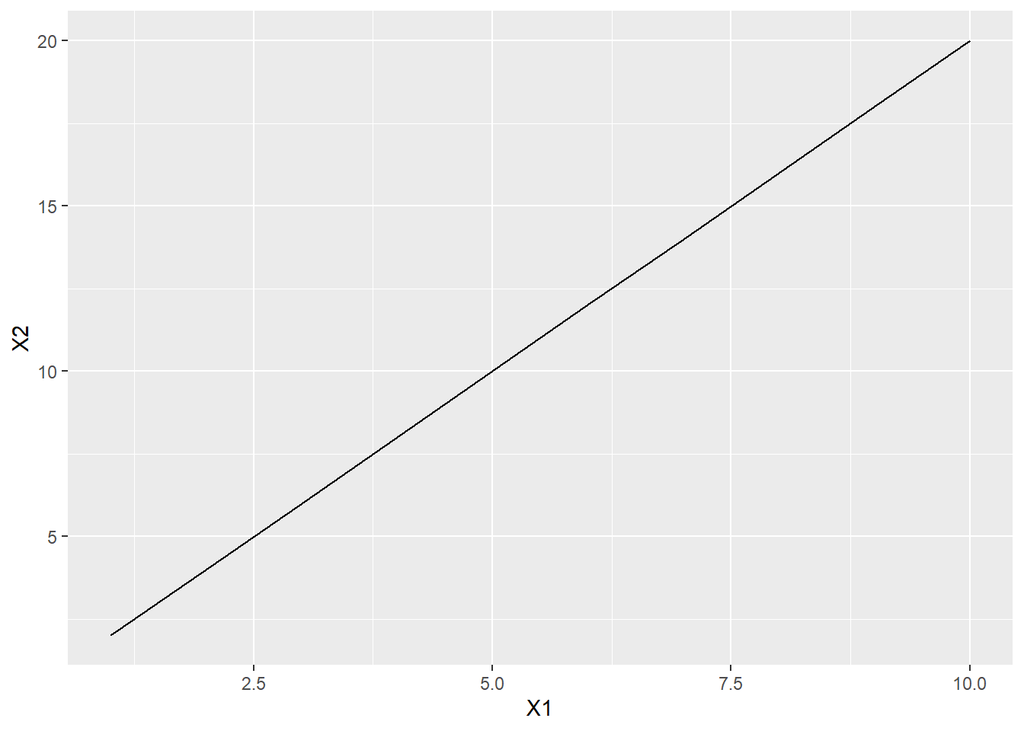

```r
dfA %>%
  ggplot(aes(x=X1,y=X2)) +
  geom_line()
```

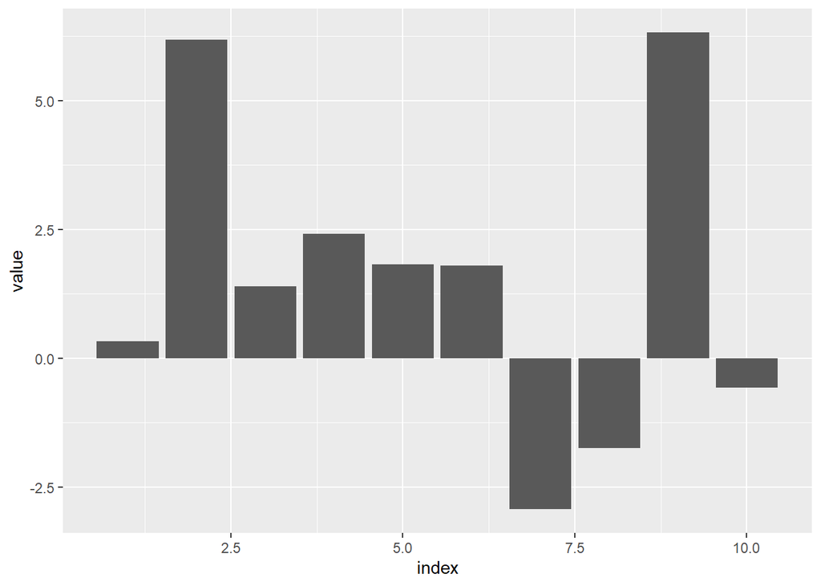

```r
dfA %>%
  ggplot(aes(X1,X5)) +
  geom_col() +
  labs(x="index",
       y="value")
```

Avec data.table : remplace dplyr dans tidyverse, pas ggplot